# Week 01

Module overview and statistical tools

Dr. Peng Zhao

2020-09-10

## Ice breaking

- Module leader: Dr. Peng Zhao
  - Email: peng.zhao@xjtlu.edu.cn (preferred)
  - Telephone: 9185 (only for emergency)
  - WeChat: unavailable

## Objectives

1. Know the general information of the module.
2. Build groups.
3. Use statistical software for importing data, calculation, and plotting graphs.
4. Create simple reports.

## Basic information

- Module name: Statistics for Environmental Scientists
- Module code: ENV203
- Credit value: 5
- Learning outcomes

  This module provides training in statistics for environmental scientists. We emphasize the use of software to analyze real environmental data. We do not assume extensive prior knowledge. We will teach the essential theory alongside the practical components.
  1. Make sense of the statistical terms that appear in scientific papers and the media
  2. Summarize data using graphs, tables, and numerical summaries
  3. Choose appropriate statistical methods to answer research questions
  4. Use statistical software to apply these methods, and interpret the output

Question: How did students perform in ENV203 in previous years and why? How can we improve the situation?

Marks of ENV203 from previous academic years (A. Y.)

| Year | $N$ | $N_\text{failure}$ | $\mu$ | $\sigma$ | min | max |
| --- | --- | --- | --- | --- | --- | --- |
| 2018/19 | 7 | 4 | 34.6 | 9.8 | 20 | 50 |
| 2019/20 | 17 | 9 | 36.5 | 15.36 | 9 | 57.5 |
| 2020/21 | 60 | ? | ? | ? | ? | ? |

(ref:fig-previous-ay) Pie charts of the Statistics of ENV203 from previous academic years

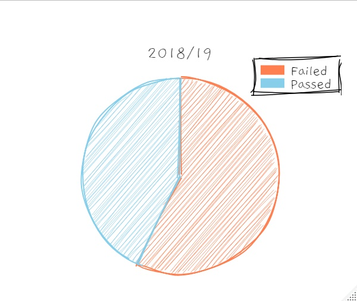

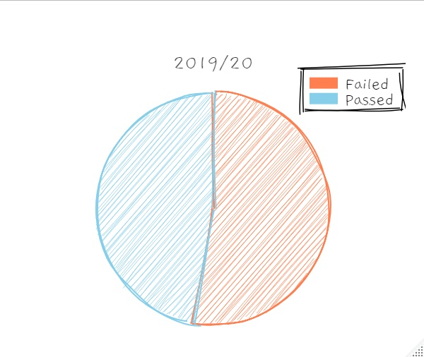

Possible reasons of high failure rate:

1. Statistical tools: R is difficult for beginners.
2. Co-taught with Environmental Science, Bioinformatics and Public Health students: Some demonstrations might be easy to some students, but hard for others.
3. A lack of engagement in class: Reading materials were not completed; Absent from class.
4. Missing deadlines for submissions.

Question: what else do you think?

Actions:

1. Statistical tools: flexible. You can use any software/hardware to do the course works and exam. However, only R will be showed in class.
2. Programs on which the module is shared: Environmental Science, Bioinformatics.
3. On-site exercises. Group work.
4. Finish your work in advance.
5. More exercises, TAs, office hours, appointments, etc..

## Assessments

There are three assessment tasks associated with this module, including two individual reports each worth 20%, and the final examination which is two hours long, worth 60% of the module mark, and will consist of short answer questions.

1. Coursework 1 (20%)
   - Release: Learning Mall, Wednesday, 30 September
   - Submission deadline: Learning Mall, Tuesday, 13 October, 23:59
2. Coursework 2 (20%)
   - Release: Learning Mall, Wednesday, 18 November
   - Submission deadline: Learning Mall, Tuesday, 1 December, 23:59
3. Final Exam (60%): Learning Mall, Two hours long and will consist of short answer questions.

Submissions:

- All the assessments must be submitted on the Learning Mall. Emails are not accepted!
- All the assessments must be submitted in .pdf file or .html file. MS Word is not accepted!
- All the assessments must be submitted on time. No delay!

## Participants

### TAs

- Xiaoyu Shi
- Shanxing Gong
- Alex Denton

### Students

Question: What are the genders and majors of the students? How many students are off campus?

(ref:fig-student-env203) Bar charts of the statistics of ENV203 of A.Y. 2020/21

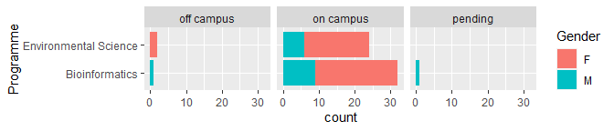

Action: Every 3 or 4 persons build a group and sit close.

Demonstration: Randomly choose a group.

- An anonymous survey:
  1. Gender: male or female?
  2. Star sign (Zodiac): Aries, Taurus, Gemini, Cancer, Leo, Virgo, Libra, Scorpio, Sagittarius, Capricorn, Aquarius, Pisces
  3. Height (in centimeters)
  4. Weight (in kilograms)
  5. Shoe size (Chinese system)
  6. Where are you from? Give a number from 1. South China (Nanfang); 2. North China (Beifang); 3. Other places or not sure.
  7. Do you like the life in Suzhou? Very much; Yes; Hard to say; No; I hate it.
  8. Body temperature today (°C)

Fill with NA if confidential or unavailable.

Demonstration: Anonymous Survey

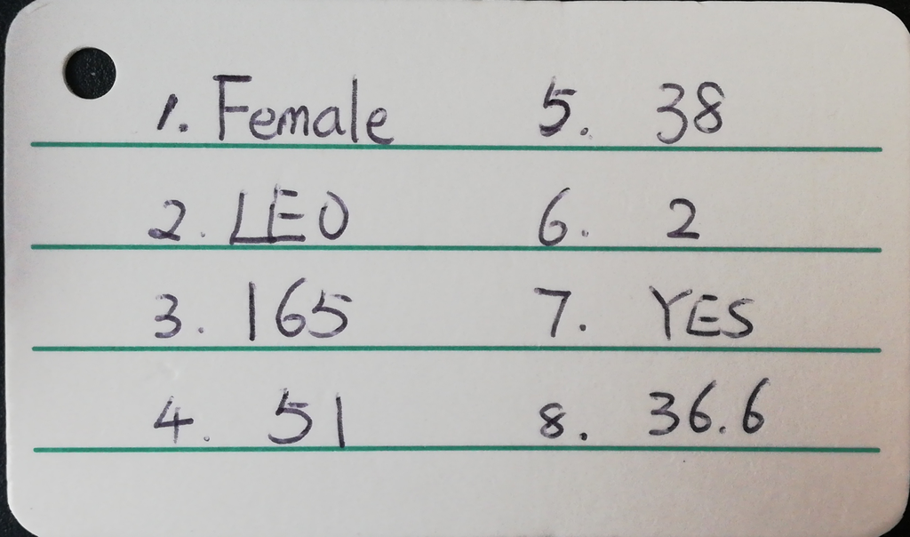

Demonstration of an anonymous survey

## Delivery schedule

- Lectures/Tutorials/Practice
  - Wednesdays 9:00 to 13:00 (Beijing Time)
  - ES209
  - Live lecture on BBB with video recording (9:00 - 11:00)
  - TAs: Xiaoyu and Shanxing (11:00 - 13:00)
- Office hours
  - Wednesdays 14:30 to 16:00
  - ES328
- Learning Mall
  - Learning materials
  - Announcements
  - Assessments
- Suggestions for students who are not in campus
  - Learn the teaching materials in advance.
  - Join the Wednesday lectures from 9:00 to 11:00 if you can. Otherwise, watch the video records afterward.
  - Join the Wednesday practice from 11:00 to 13:00 if you can. Otherwise, do the exercise on your own.
  - Consult the online TA: Alex, on BBB, Wednesday 17:00 - 19:00 (Beijing Time)

Demonstration: Usague of the Learning Mall

## Syllabus

Lectures and demonstrations will provide background on the theory. Exercise sessions will give practical experience in data analysis. Feedback will be given on these sessions. Individual and group projects will use all the skills taught in lectures and workshops.

Syllabus of ENV203

| Week | Topic |
| --- | --- |
| 1 | Module overview and statistical software |
| 2 | Basic concepts |
| 3 | Quantitative data |
| 4 | Qualitative data |
| 5 | Normal distributions |
| 6 | *t* distribution |
| 7 | Other distributions |
| 8 | NO CLASSES (Mid-term) |
| 9 | Correlation |
| 10 | Regression |
| 11 | Statistical tables and graphs |
| 12 | Hypothesis testing |
| 13 | Testing two parameters |
| 14 | Analysis of variance |

## Readings

- Takahashi S. (2009). *The Manga Guide to Statistics*. San Francisco: No Starch Press.
- Abbas A. and Alqaraghuli W. (2019). *Applied Statistics for Environmental Science with R*. Elsevier.
- Triola MM, Triola MF, Roy J. (2019). *Biostatistics for the Biological and Health Sciences*. 2nd Edition. Harlow, United Kingdom: Pearson.
- Wickham H. and Garrett G. (2016). *R for Data Science: Import, Tidy, Transform, Visualize, and Model Data.* O’Reilly Media, Inc. <URL: https://r4ds.had.co.nz/>.
- Zhao P. and Li Y. (2018). *Learning R: From the Very Beginning.* In Chinese. Research Press. <URL: http://xuer.pzhao.org/>.
- Xie Y., Huang Y., Zhao P. (2020). *Modern Statistical Graphics*. In Chinese. <URL: https://msg-book.netlify.com/>.

## Tools for statistics

Pre-requisites needed for the module: Nil.

The poll function on BBB: Who has experience in R, SPSS, Excel, or other software which can do statistics?

## R essentials

### Installation

1. Open the [home page](https://cran.r-project.org) of the R official website.
2. Windows users click `Download R for Windows` - `base` - `Download R x.x.x for Windows` (x.x.x is the version, e.g. 4.0.2) at the top of the webpage, and the installation file will be downloaded. Mac and Linux users can find the related files.
3. Double click the downloaded file and follow the instruction until it is installed.
4. Open the [download page](https://rstudio.com/products/rstudio/download/#download) on the RStudio official website.
5. Click ‘DOWNLOAD RSTUDIO FOR xxx’.
6. Double click the downloaded file and follow the instruction until it is installed.

Demonstration: Installation of R & RStudio

### RStudio

Say hello to RStudio.

(ref:fig-rstudio) RStudio interface.

[figure not shown]

Use hotkeys:

- ctrl + enter (run the line where the cursor is)
- TAB (complete names of functions and objects)
- F1 (get help)
- shift + alt + k (see all shortcuts)

Create an R project:

- File - New project - New directory - New project
- Organize your R scripts and products in a project:
- Save your related files in the project folder
- Start your work from the .Rproj file

Demonstration: R project

### Save your script

Two recommended ways to save your script:

1. In a .R file
- File - New File - R Script. Hotkey ctrl+shift+N
2. In a .Rmd file
- File - New File - R Markdown
- Click the `knit` button, which knits it into a .html file.
- Now you can remove the lines from `{r setup, include=FALSE}` to the end and put your R script in chunks.

Demonstration: .R file and .Rmd file

### Basic operations

Simple Maths:

```r
1 + 2 - 4 * 5 / 6 ^ 2
```

```
## [1] 2.444444
```

```r
1 + 2 + 3
```

```
## [1] 6
```

```r
(1 + 2) * 3
```

```
## [1] 9
```

```r
3.14 * 4 ^ 2
```

```
## [1] 50.24
```

```r
2 ^ 0.5
```

```
## [1] 1.414214
```

Vectors:

> A vector is a sequence of data elements of the same basic type. It is the simplest type of data structure in R.

> — http://www.r-tutor.com/r-introduction/vector

This is a vector:

```r
c(1, 3, 5, 7)
```

```
## [1] 1 3 5 7
```

Calculation of a vector and a number:

```r
c(1, 3, 5, 7) + 10
```

```
## [1] 11 13 15 17
```

```r
c(1, 3, 5, 7) ^ 2
```

```
## [1]  1  9 25 49
```

Calculation of two vectors:

```r
c(1, 2, 3, 4) + c(10, 20, 30, 40)
```

```
## [1] 11 22 33 44
```

Sequence:

```r
c(1, 2, 3, 4, 5, 6, 7, 8, 9) ^ 2
(1:9) ^ 2
9:1
1 / (9:1)
```

Functions:

```r
(1:9) ^ 0.5
```

```
## [1] 1.000000 1.414214 1.732051 2.000000 2.236068 2.449490 2.645751 2.828427
## [9] 3.000000
```

```r
sqrt(1:9)
```

```
## [1] 1.000000 1.414214 1.732051 2.000000 2.236068 2.449490 2.645751 2.828427
## [9] 3.000000
```

```r
exp(1:9)
```

```
## [1]    2.718282    7.389056   20.085537   54.598150  148.413159  403.428793
## [7] 1096.633158 2980.957987 8103.083928
```

```r
log(1:9)
```

```
## [1] 0.0000000 0.6931472 1.0986123 1.3862944 1.6094379 1.7917595 1.9459101
## [8] 2.0794415 2.1972246
```

```r
log10(1:9)
```

```
## [1] 0.0000000 0.3010300 0.4771213 0.6020600 0.6989700 0.7781513 0.8450980
## [8] 0.9030900 0.9542425
```

```r
round(3.14)
```

```
## [1] 3
```

Objects:

```r
x <- 1:9  # alt+_
# comment
x
```

```
## [1] 1 2 3 4 5 6 7 8 9
```

```r
x = 1:9
x
```

```
## [1] 1 2 3 4 5 6 7 8 9
```

```r
x ^ 2
```

```
## [1]  1  4  9 16 25 36 49 64 81
```

```r
x[7]
```

```
## [1] 7
```

```r
x[c(1,3,8)]
```

```
## [1] 1 3 8
```

```r
x[1:6]
```

```
## [1] 1 2 3 4 5 6
```

```r
y <- 11:19
y
```

```
## [1] 11 12 13 14 15 16 17 18 19
```

```r
x + y
```

```
## [1] 12 14 16 18 20 22 24 26 28
```

```r
c(x, y)
```

```
##  [1]  1  2  3  4  5  6  7  8  9 11 12 13 14 15 16 17 18 19
```

Use functions on objects:

```r
sqrt(x)
```

```
## [1] 1.000000 1.414214 1.732051 2.000000 2.236068 2.449490 2.645751 2.828427
## [9] 3.000000
```

```r
exp(x)
```

```
## [1]    2.718282    7.389056   20.085537   54.598150  148.413159  403.428793
## [7] 1096.633158 2980.957987 8103.083928
```

```r
log(x)
```

```
## [1] 0.0000000 0.6931472 1.0986123 1.3862944 1.6094379 1.7917595 1.9459101
## [8] 2.0794415 2.1972246
```

```r
log10(x)
```

```
## [1] 0.0000000 0.3010300 0.4771213 0.6020600 0.6989700 0.7781513 0.8450980
## [8] 0.9030900 0.9542425
```

```r
mean(x)
```

```
## [1] 5
```

```r
min(x)
```

```
## [1] 1
```

```r
max(x)
```

```
## [1] 9
```

```r
range(x)
```

```
## [1] 1 9
```

```r
sd(x)
```

```
## [1] 2.738613
```

Q: How can I memorize the function names?

A: TAB and F1.

### Data frame

Manual input:

```r
df_manual <- data.frame(age = c(21, 31, 23, 40, 36),
                  gender = c('f', 'm', 'm', 'f', 'f'))
df_manual
```

```
##   age gender
## 1  21      f
## 2  31      m
## 3  23      m
## 4  40      f
## 5  36      f
```

Normally, we edit the data in another program, save it as a .csv file, and import it into R.

Demonstration: The New York Air Quality dataset shows daily air quality measurements in New York, May to September 1973. The measurements include mean ozone in parts per billion from 1300 to 1500 hours at Roosevelt Island, solar radiation in Langleys in the frequency band 4000–7700 Angstroms from 0800 to 1200 hours at Central Park, average wind speed in miles per hour at 0700 and 1000 hours at LaGuardia Airport, maximum daily temperature in degrees Fahrenheit at La Guardia Airport.

1. Download airquality.csv from the Learning Mall.
2. Open it with Excel. Take a look. Close it.
3. Open it with Notepad. Take a look. Close it.
4. Import it into R.

```r
df_aq <- read.csv('data/airquality.csv')
summary(df_aq)
```

```
##      Ozone           Solar.R           Wind             Temp
##  Min.   :  1.00   Min.   :  7.0   Min.   : 1.700   Min.   :56.00
##  1st Qu.: 18.00   1st Qu.:115.8   1st Qu.: 7.400   1st Qu.:72.00
##  Median : 31.50   Median :205.0   Median : 9.700   Median :79.00
##  Mean   : 42.13   Mean   :185.9   Mean   : 9.958   Mean   :77.88
##  3rd Qu.: 63.25   3rd Qu.:258.8   3rd Qu.:11.500   3rd Qu.:85.00
##  Max.   :168.00   Max.   :334.0   Max.   :20.700   Max.   :97.00
##  NA's   :37       NA's   :7
##      Month            Day
##  Min.   :5.000   Min.   : 1.0
##  1st Qu.:6.000   1st Qu.: 8.0
##  Median :7.000   Median :16.0
##  Mean   :6.993   Mean   :15.8
##  3rd Qu.:8.000   3rd Qu.:23.0
##  Max.   :9.000   Max.   :31.0
##
```

If you don’t like codes, click File - Import Dataset - From Text (base), and choose airquality.csv. You will get an object with the same name as the file name `airquality` rather than `df_aq`.

Indexing:

```r
df_aq[2, 4]
```

```
## [1] 72
```

```r
df_aq[2, 1:5]
```

```
##   Ozone Solar.R Wind Temp Month
## 2    36     118    8   72     5
```

```r
df_aq[2, ]
```

```
##   Ozone Solar.R Wind Temp Month Day
## 2    36     118    8   72     5   2
```

```r
df_aq[, 3]
```

```
##   [1]  7.4  8.0 12.6 11.5 14.3 14.9  8.6 13.8 20.1  8.6  6.9  9.7  9.2 10.9 13.2
##  [16] 11.5 12.0 18.4 11.5  9.7  9.7 16.6  9.7 12.0 16.6 14.9  8.0 12.0 14.9  5.7
##  [31]  7.4  8.6  9.7 16.1  9.2  8.6 14.3  9.7  6.9 13.8 11.5 10.9  9.2  8.0 13.8
##  [46] 11.5 14.9 20.7  9.2 11.5 10.3  6.3  1.7  4.6  6.3  8.0  8.0 10.3 11.5 14.9
##  [61]  8.0  4.1  9.2  9.2 10.9  4.6 10.9  5.1  6.3  5.7  7.4  8.6 14.3 14.9 14.9
##  [76] 14.3  6.9 10.3  6.3  5.1 11.5  6.9  9.7 11.5  8.6  8.0  8.6 12.0  7.4  7.4
##  [91]  7.4  9.2  6.9 13.8  7.4  6.9  7.4  4.6  4.0 10.3  8.0  8.6 11.5 11.5 11.5
## [106]  9.7 11.5 10.3  6.3  7.4 10.9 10.3 15.5 14.3 12.6  9.7  3.4  8.0  5.7  9.7
## [121]  2.3  6.3  6.3  6.9  5.1  2.8  4.6  7.4 15.5 10.9 10.3 10.9  9.7 14.9 15.5
## [136]  6.3 10.9 11.5  6.9 13.8 10.3 10.3  8.0 12.6  9.2 10.3 10.3 16.6  6.9 13.2
## [151] 14.3  8.0 11.5
```

```r
df_aq$Wind
```

Each column is a vector. Use the vector operation mentioned before.

Calculation:

```r
# Convert Wind from mph (mile per hour) to m/s (meter per second)
df_aq$Wind * 1.609344 * 1000 / 3600
```

```
##   [1] 3.308096 3.576320 5.632704 5.140960 6.392672 6.660896 3.844544 6.169152
##   [9] 8.985504 3.844544 3.084576 4.336288 4.112768 4.872736 5.900928 5.140960
##  [17] 5.364480 8.225536 5.140960 4.336288 4.336288 7.420864 4.336288 5.364480
##  [25] 7.420864 6.660896 3.576320 5.364480 6.660896 2.548128 3.308096 3.844544
##  [33] 4.336288 7.197344 4.112768 3.844544 6.392672 4.336288 3.084576 6.169152
##  [41] 5.140960 4.872736 4.112768 3.576320 6.169152 5.140960 6.660896 9.253728
##  [49] 4.112768 5.140960 4.604512 2.816352 0.759968 2.056384 2.816352 3.576320
##  [57] 3.576320 4.604512 5.140960 6.660896 3.576320 1.832864 4.112768 4.112768
##  [65] 4.872736 2.056384 4.872736 2.279904 2.816352 2.548128 3.308096 3.844544
##  [73] 6.392672 6.660896 6.660896 6.392672 3.084576 4.604512 2.816352 2.279904
##  [81] 5.140960 3.084576 4.336288 5.140960 3.844544 3.576320 3.844544 5.364480
##  [89] 3.308096 3.308096 3.308096 4.112768 3.084576 6.169152 3.308096 3.084576
##  [97] 3.308096 2.056384 1.788160 4.604512 3.576320 3.844544 5.140960 5.140960
## [105] 5.140960 4.336288 5.140960 4.604512 2.816352 3.308096 4.872736 4.604512
## [113] 6.929120 6.392672 5.632704 4.336288 1.519936 3.576320 2.548128 4.336288
## [121] 1.028192 2.816352 2.816352 3.084576 2.279904 1.251712 2.056384 3.308096
## [129] 6.929120 4.872736 4.604512 4.872736 4.336288 6.660896 6.929120 2.816352
## [137] 4.872736 5.140960 3.084576 6.169152 4.604512 4.604512 3.576320 5.632704
## [145] 4.112768 4.604512 4.604512 7.420864 3.084576 5.900928 6.392672 3.576320
## [153] 5.140960
```

```r
wind_ms <- df_aq$Wind * 1.609344 * 1000 / 3600
df_aq$wind_ms <- df_aq$Wind * 1.609344 * 1000 / 3600
```

Export data:

```r
write.csv(df_aq, "data/airquality_new.csv")
```

Double check:

1. Open “data/airquality_new.csv” with Excel. Take a look. Close it.
2. Open “data/airquality_new.csv” with Notepad. Take a look. Close it.

Demo: Excel and Notepad. Notepad++.

### Visualization

We plot some ugly graphs, including three scatter plots, a histogram, a box plot, a pair plot:

```r
x
```

```
## [1] 1 2 3 4 5 6 7 8 9
```

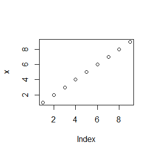

```r
plot(x)
```

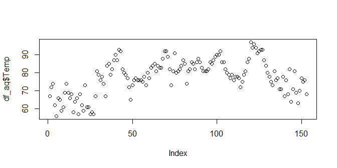

```r
plot(df_aq$Temp)
```

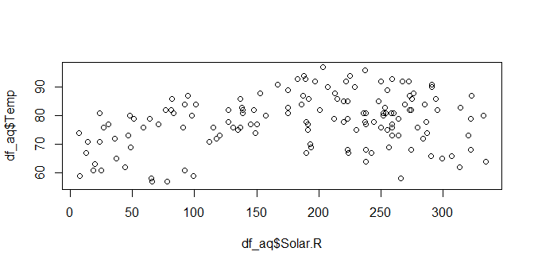

```r
plot(df_aq$Solar.R, df_aq$Temp)
```

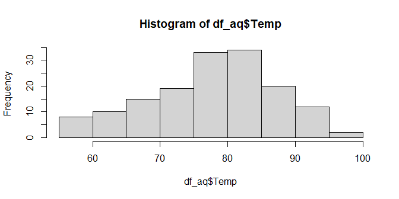

```r
hist(df_aq$Temp)
```

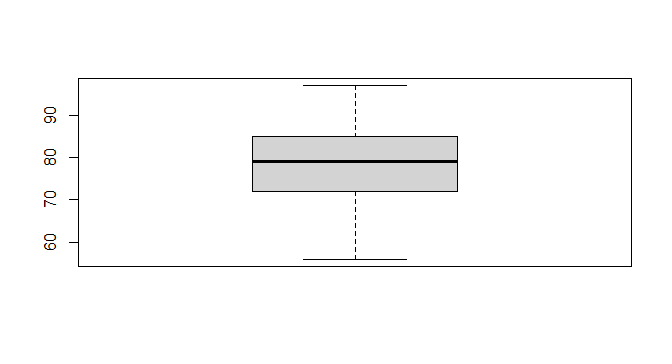

```r
boxplot(df_aq$Temp)
```

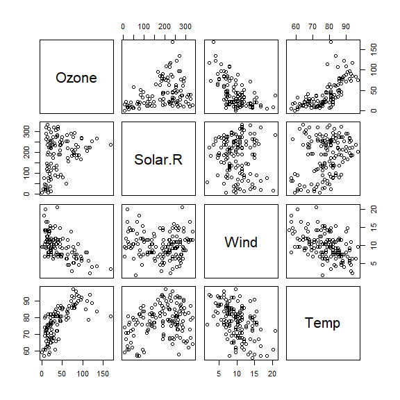

```r
pairs(df_aq[, 1:4])
```

Some fancy graphs:

```r
install.packages("ggplot2")
library(ggplot2)
```

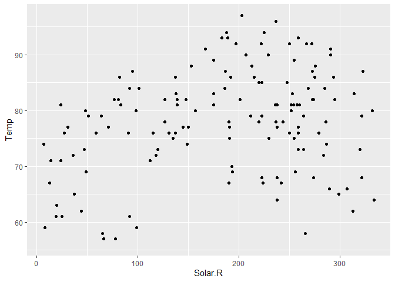

```r
ggplot(df_aq) + geom_point(aes(x = Solar.R, y = Temp))
```

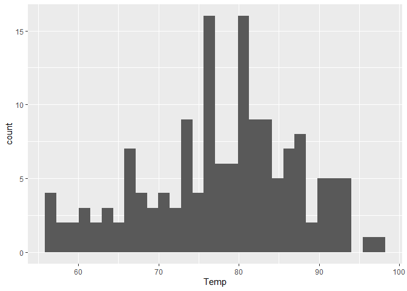

```r
ggplot(df_aq) + geom_histogram(aes(Temp))
```

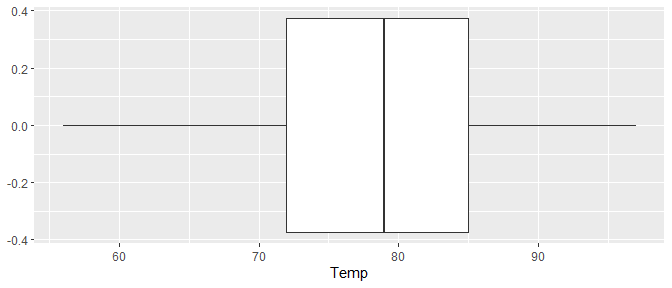

```r
ggplot(df_aq) + geom_boxplot(aes(Temp))
```

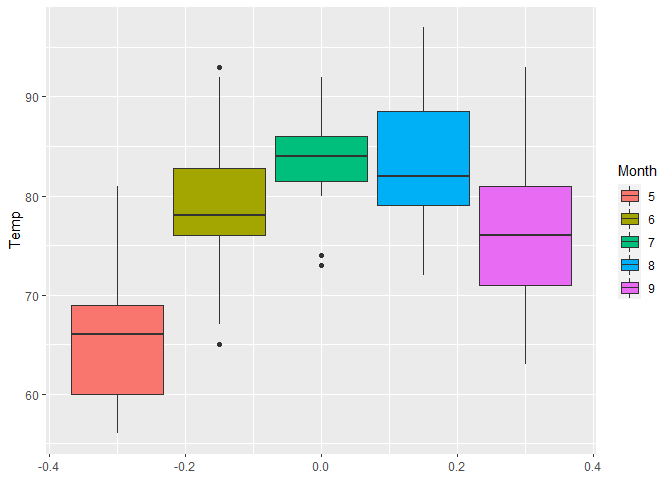

```r
df_aq$Month <- as.character(df_aq$Month)
ggplot(df_aq) + geom_boxplot(aes(y = Temp, fill = Month))
```

```r
install.packages("GGally")
library(GGally)
```

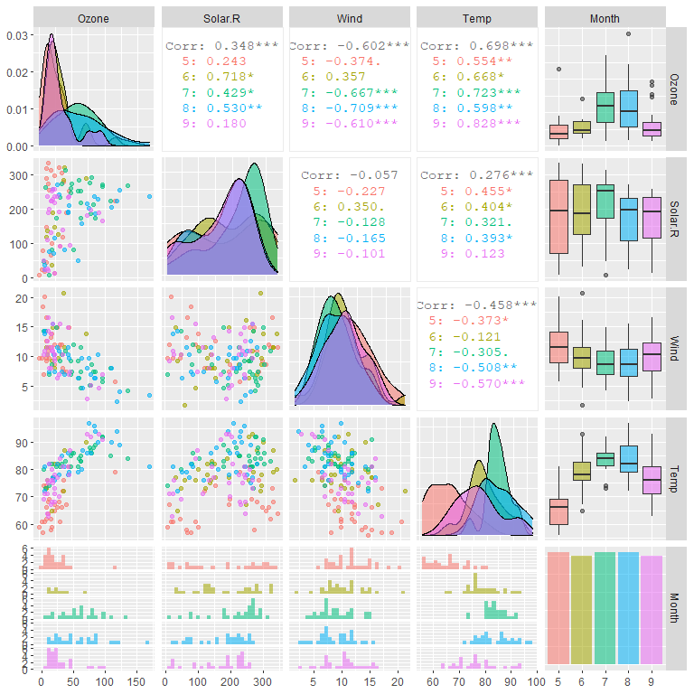

```r
library(GGally)
ggpairs(df_aq[, 1:5], aes(colour=Month, alpha=0.5))
```

Save graphs:

1. In RStudio, click Plots - Export - Save as PDF. Or
2. Use functions:

```r
pdf('df_plot.pdf')
plot(df_aq$Temp)
dev.off()
```

```r
ggpairs(df_aq[, 1:5], aes(colour=Month, alpha=0.5))
ggsave("df_ggpairs.pdf")
```

## Assignments

- Read: *A (very) short introduction to R*
- Read (optional): *Learning R (in Chinese)* , Chapter 1
- Read: A very short introduction to R Markdown
- Prepare for the role play by two randomly chosen groups: *The Manga Guide to Statistics*: Prologue & Data types

## Exercises

**Installation**

Install R, RStudio and some packages if you are going to use R for this semester.

1. Install R and RStudio in your own computer.
2. Install the R packages **ggplot2** and **GGally** in your own computer.

Prepare the software you want to use if not R.

**Digitization**

6 Groups are randomly chosen to digitized the students’ survey.

1. Download the students203_blanck.csv file from the Learning Mall.
2. Open students203_blanck.csv in Excel.
3. Input the data in the questionnaires assigned to you to students203_blanck.csv.
4. Save it as a new .csv file.
5. Open the new .csv file in Notepad or any other plain text editor. Copy all, and paste in the General Q&A forum on the Learning Mall.
6. The module leader will merge all files into one single file for future use.

**Reproduction**

Repeat the examples given in the lecture. You can use any software or hardware.

If you can reproduce the examples fast, you could try using different software to do the same work, such as R and Excel, and compare them.

What is the advantage of Excel-like software and R-like software, respectively?

**Simple Maths**

1. Calculate $1 + 2 + 3 + ... + 100$.
2. Calculate the circumference and area of a circle with a radius of 10 m, 20 m, 30 m, 40 m, 60 m.
3. $y = e^{ax} + b$, $a = 3.2$, $b = 98$. Calculate the $y$ values when $x = 0.2, 2, 20, 200$.

**New York air quality**

The New York Air Quality dataset shows daily air quality measurements in New York, May to September 1973. The measurements include mean ozone in parts per billion from 1300 to 1500 hours at Roosevelt Island, solar radiation in Langleys in the frequency band 4000–7700 Angstroms from 0800 to 1200 hours at Central Park, average wind speed in miles per hour at 0700 and 1000 hours at LaGuardia Airport, maximum daily temperature in degrees Fahrenheit at La Guardia Airport.

Download the airquality.csv file from the Learning Mall and import it into R or other software.

1. How many rows and columns does this data frame have?
2. What was the temperature on June 22?
3. What was the mean early afternoon ozone concentration (ppb) in June?
4. What was the mean, maximum, minimum, median of the morning wind speed in the whole dataset?
5. The temperature in the dataset was given in $^\circ$F. Add a new column for the temperature in $^\circ$C.
6. Make a boxplot of the early afternoon ozone concentration in June.
7. Make a histogram of the early afternoon ozone concentration in June.
8. Save the data frame as a .csv file
9. Save the boxplot and histogram as .pdf files.
10. Report all the results above in a .pdf file or .html file.

**ENV203 students**

Download the students203.csv file from the Learning Mall and import it into R or other software.

1. How many rows and columns does this data frame have?
2. What is the star sign of the student No. 16?
3. What is the mean height of all the students?
4. What is the mean, maximum, minimum, median of the shoe size in the whole dataset?
5. How many students like the life in Suzhou very much?
6. Body mass index (BMI) is a measure of body fat based on height and weight that applies to adult men and women. Add a new column as the BMI.
7. Make a scatter plot for the weight agains the height.
8. Make a histogram of the BMI for the male students. Hint: use `which(df203$Gender == "male")` to choose the indice of male students.
9. Make a pair plot of all the numeric variables in the dataset. Using different colors for each gender.
10. Save the data frame as a .csv file
11. Save the boxplot and histogram as .pdf files.
12. Report all the results above in a .pdf file or .html file.

**Groundwater TCE**

Trichloroethylene (TCE) is reported by the EPA to be the most prevalent solvent contaminating groundwater at superfund sites in the United States. Exposure can result in effects to the immune and reproductive systems, liver, kidneys, central nervous system, and may affect fetal development during pregnancy. Long term exposures to TCE can increase the risk of kidney cancer. There is also evidence that TCE exposure can increase the risk for non-Hodgkin’s lymphoma and liver cancer.

The “tce” dataset shows the TCE concentrations (mg/L) at 10 randomly selected groundwater monitoring wells before remediation and the same wells after remediation. Download the tce.csv file from the Learning Mall and import it into R or other software.

1. How many rows and columns does this data frame have?
2. What were the TCE concentrations of the well No. 5 before and after remediation?
3. What were the mean, maximum, minimum, median of the TCE concentrations of all the wells before and after remediation, respectively?
4. Make a boxplot for the TCE concentrations before and after remediation, respectively.
5. Save the boxplot and histogram as pdf files.
6. Report all the results above in a .pdf file or .html file.